# Tarea 2_Ricardo Zamora Mennigke_Mineria de Datos I

```r
tam<-dim(data1)
n<-tam[1]
n
```

```
## [1] 1275
```

```r
muestra <- sample(1:n,floor(n*0.25))
ttesting <- data1[muestra,]
taprendizaje <- data1[-muestra,]
# train.kknn escoje el k usando leave-one-out crossvalidation
modelo<-train.kknn(tipo~.,data=taprendizaje,kmax=floor(sqrt(n)))
modelo
```

```
##
## Call:
## train.kknn(formula = tipo ~ ., data = taprendizaje, kmax = floor(sqrt(n)))
##
## Type of response variable: nominal
## Minimal misclassification: 0.05329154
## Best kernel: optimal
## Best k: 9
```

```r
prediccion<-predict(modelo,ttesting[,-18])
prediccion
```

```
##   [1] 1 0 1 1 1 1 1 0 0 0 1 1 1 1 1 1 1 1 1 1 1 1 1 0 1 1 1 1 0 1 1 1 1 1 1 1 1
##  [38] 1 1 1 1 1 1 1 1 1 1 1 1 1 1 1 1 1 1 1 1 1 1 1 1 1 1 1 1 1 1 1 1 1 1 1 1 1
##  [75] 1 1 1 1 1 1 1 1 1 0 0 1 1 1 1 1 1 1 1 1 1 1 0 1 1 1 1 1 1 1 1 1 1 1 1 0 1
## [112] 1 1 1 1 1 1 1 1 1 1 1 1 1 1 1 1 1 0 1 1 1 1 1 1 1 1 1 1 1 1 1 1 1 1 1 1 1
## [149] 1 1 1 1 1 1 1 1 1 1 1 1 1 1 1 1 1 1 1 0 1 1 1 1 1 1 1 1 1 1 1 0 1 1 1 1 1
## [186] 1 1 1 1 1 0 1 1 1 1 1 1 1 1 1 1 1 1 1 1 1 1 1 1 1 1 1 1 1 0 1 1 1 1 1 1 0
## [223] 1 1 1 1 1 1 1 1 1 1 1 1 1 1 1 1 1 1 1 1 1 1 1 1 1 1 1 1 1 1 1 1 1 1 1 1 1
## [260] 1 1 1 1 1 1 1 1 1 1 1 1 1 1 1 0 1 1 0 1 1 1 1 1 1 1 1 1 1 1 0 1 1 1 1 1 1
## [297] 1 1 1 1 1 1 1 1 1 1 1 1 1 1 1 1 1 1 1 1 1 1
## Levels: 0 1
```

```r
## Matriz de Confusión
MC<-table(ttesting[,18],prediccion)
# Índices de Calidad de la predicción
indices.general(MC)
```

```
## $`Matriz de Confusión`
##    prediccion
##       0   1
##   0  14   8
##   1   5 291
##
## $`Precisión Global`
## [1] 0.9591195
##
## $`Error Global`
## [1] 0.0408805
##
## $`Precisión por categoría`
##         0         1
## 0.6363636 0.9831081
##
## $`Precision Positiva`
## [1] 0.9831081
##
## $`Precision Negativa`
## [1] 0.6363636
##
## $`Falsos Positivos`
## [1] 0.3636364
##
## $`Falsos Negativos`
## [1] 0.01689189
##
## $`Asertividad Positiva`
## [1] 0.9732441
##
## $`Asertividad Negativa`
## [1] 0.7368421
```

##Genere un Modelo Predictivo usando K vecinos m´as cercanos para cada uno de los siguientes n´ucleos: rectangular, triangular, epanechnikov, biweight, triweight, cos, inv, gaussian y optimal ¿Cu´al produce los mejores resultados en el sentido de que predice mejor los tumores, es decir, Tumor = 1.

```r
modelo.rectangular<-train.kknn(tipo~.,data=taprendizaje,kmax=floor(sqrt(n)), kernel = "rectangular")
modelo.rectangular
```

```
##
## Call:
## train.kknn(formula = tipo ~ ., data = taprendizaje, kmax = floor(sqrt(n)),     kernel = "rectangular")
##
## Type of response variable: nominal
## Minimal misclassification: 0.05642633
## Best kernel: rectangular
## Best k: 4
```

```r
modelo.triangular<-train.kknn(tipo~.,data=taprendizaje,kmax=floor(sqrt(n)), kernel = "triangular")
modelo.triangular
```

```
##
## Call:
## train.kknn(formula = tipo ~ ., data = taprendizaje, kmax = floor(sqrt(n)),     kernel = "triangular")
##
## Type of response variable: nominal
## Minimal misclassification: 0.05747126
## Best kernel: triangular
## Best k: 11
```

```r
modelo.epanechnikov<-train.kknn(tipo~.,data=taprendizaje,kmax=floor(sqrt(n)), kernel = "epanechnikov")
modelo.epanechnikov
```

```
##
## Call:
## train.kknn(formula = tipo ~ ., data = taprendizaje, kmax = floor(sqrt(n)),     kernel = "epanechnikov")
##
## Type of response variable: nominal
## Minimal misclassification: 0.05642633
## Best kernel: epanechnikov
## Best k: 11
```

```r
modelo.biweight<-train.kknn(tipo~.,data=taprendizaje,kmax=floor(sqrt(n)), kernel = "biweight")
modelo.biweight
```

```
##
## Call:
## train.kknn(formula = tipo ~ ., data = taprendizaje, kmax = floor(sqrt(n)),     kernel = "biweight")
##
## Type of response variable: nominal
## Minimal misclassification: 0.0585162
## Best kernel: biweight
## Best k: 19
```

```r
modelo.triweight<-train.kknn(tipo~.,data=taprendizaje,kmax=floor(sqrt(n)), kernel = "triweight")
modelo.triweight
```

```
##
## Call:
## train.kknn(formula = tipo ~ ., data = taprendizaje, kmax = floor(sqrt(n)),     kernel = "triweight")
##
## Type of response variable: nominal
## Minimal misclassification: 0.0585162
## Best kernel: triweight
## Best k: 30
```

```r
modelo.cos<-train.kknn(tipo~.,data=taprendizaje,kmax=floor(sqrt(n)), kernel = "cos")
modelo.cos
```

```
##
## Call:
## train.kknn(formula = tipo ~ ., data = taprendizaje, kmax = floor(sqrt(n)),     kernel = "cos")
##
## Type of response variable: nominal
## Minimal misclassification: 0.05642633
## Best kernel: cos
## Best k: 11
```

```r
modelo.inv<-train.kknn(tipo~.,data=taprendizaje,kmax=floor(sqrt(n)), kernel = "inv")
modelo.inv
```

```
##
## Call:
## train.kknn(formula = tipo ~ ., data = taprendizaje, kmax = floor(sqrt(n)),     kernel = "inv")
##
## Type of response variable: nominal
## Minimal misclassification: 0.0585162
## Best kernel: inv
## Best k: 4
```

```r
modelo.gaussian<-train.kknn(tipo~.,data=taprendizaje,kmax=floor(sqrt(n)), kernel = "gaussian")
modelo.gaussian
```

```
##
## Call:
## train.kknn(formula = tipo ~ ., data = taprendizaje, kmax = floor(sqrt(n)),     kernel = "gaussian")
##
## Type of response variable: nominal
## Minimal misclassification: 0.0585162
## Best kernel: gaussian
## Best k: 4
```

```r
modelo.optimal<-train.kknn(tipo~.,data=taprendizaje,kmax=floor(sqrt(n)), kernel = "optimal")
modelo.optimal
```

```
##
## Call:
## train.kknn(formula = tipo ~ ., data = taprendizaje, kmax = floor(sqrt(n)),     kernel = "optimal")
##
## Type of response variable: nominal
## Minimal misclassification: 0.05329154
## Best kernel: optimal
## Best k: 9
```

```r
prediccion1<-predict(modelo.rectangular,ttesting[,-18])
prediccion1
```

```
##   [1] 1 0 1 1 1 1 1 0 0 0 1 1 1 1 1 1 1 1 1 1 1 1 1 0 1 1 1 1 0 1 1 1 1 1 1 1 1
##  [38] 1 1 1 1 1 1 1 1 1 1 1 1 1 1 1 1 1 1 1 1 1 1 1 1 1 1 1 1 1 1 1 1 1 1 1 1 1
##  [75] 1 1 1 1 1 1 1 1 1 0 1 1 1 1 1 1 1 1 1 1 1 1 0 1 1 1 1 1 1 1 1 1 1 1 1 0 1
## [112] 1 1 1 1 1 1 1 1 1 1 1 1 1 1 1 1 1 0 1 1 1 1 1 1 1 1 1 1 1 1 1 1 1 1 1 1 1
## [149] 1 1 1 1 1 1 1 1 1 1 1 1 1 1 1 1 1 1 1 0 1 1 1 1 1 1 1 1 1 1 1 0 1 1 1 1 1
## [186] 1 1 1 1 1 0 1 1 1 1 1 1 1 1 1 1 1 1 1 1 1 1 1 1 1 1 1 1 1 0 1 1 1 1 1 1 0
## [223] 1 1 1 1 1 1 1 1 1 1 1 0 1 1 1 1 1 1 1 1 1 1 1 1 1 1 1 1 1 1 1 1 1 1 1 1 1
## [260] 1 1 1 1 1 1 1 1 1 1 1 1 1 1 1 0 1 1 0 1 1 1 1 1 1 1 1 1 1 1 0 1 1 0 1 1 1
## [297] 1 1 1 1 1 1 1 1 1 1 1 1 1 1 1 1 1 1 1 1 1 1
## Levels: 0 1
```

```r
prediccion2<-predict(modelo.triangular,ttesting[,-18])
prediccion2
```

```
##   [1] 1 0 1 1 1 1 1 0 0 0 1 1 1 1 1 1 1 1 1 1 1 1 1 0 1 1 1 1 0 1 1 1 1 1 1 1 1
##  [38] 1 1 1 1 1 1 1 1 1 1 1 1 1 1 1 1 1 1 1 1 1 1 1 1 1 1 1 1 1 1 1 1 1 1 1 1 1
##  [75] 1 1 1 1 1 1 1 1 1 0 1 1 1 1 1 1 1 1 1 1 1 1 0 1 1 1 1 1 1 1 1 1 1 1 1 1 1
## [112] 1 1 1 1 1 1 1 1 1 1 1 1 1 1 1 1 1 0 1 1 1 1 1 1 1 1 1 1 1 1 1 1 1 1 1 1 1
## [149] 1 1 1 1 1 1 1 1 1 1 1 1 1 1 1 1 1 1 1 0 1 1 1 1 1 1 1 1 1 1 1 0 1 1 1 1 1
## [186] 1 1 1 1 1 0 1 1 1 1 1 1 1 1 1 1 1 1 1 1 1 1 1 1 1 1 1 1 1 1 1 1 1 1 1 1 0
## [223] 1 1 1 1 1 1 1 1 1 1 1 1 1 1 1 1 1 1 1 1 1 1 1 1 1 1 1 1 1 1 1 1 1 1 1 1 1
## [260] 1 1 1 1 1 1 1 1 1 1 1 1 1 1 1 0 1 1 0 1 1 1 1 1 1 1 1 1 1 1 0 1 1 1 1 1 1
## [297] 1 1 1 1 1 1 1 1 1 1 1 1 1 1 1 1 1 1 1 1 1 1
## Levels: 0 1
```

```r
prediccion3<-predict(modelo.epanechnikov,ttesting[,-18])
prediccion3
```

```
##   [1] 1 0 1 1 1 1 1 0 0 0 1 1 1 1 1 1 1 1 1 1 1 1 1 0 1 1 1 1 0 1 1 1 1 1 1 1 1
##  [38] 1 1 1 1 1 1 1 1 1 1 1 1 1 1 1 1 1 1 1 1 1 1 1 1 1 1 1 1 1 1 1 1 1 1 1 1 1
##  [75] 1 1 1 1 1 1 1 1 1 0 1 1 1 1 1 1 1 1 1 1 1 1 0 1 1 1 1 1 1 1 1 1 1 1 1 1 1
## [112] 1 1 1 1 1 1 1 1 1 1 1 1 1 1 1 1 1 0 1 1 1 1 1 1 1 1 1 1 1 1 1 1 1 1 1 1 1
## [149] 1 1 1 1 1 1 1 1 1 1 1 1 1 1 1 1 1 1 1 0 1 1 1 1 1 1 1 1 1 1 1 0 1 1 1 1 1
## [186] 1 1 1 1 1 0 1 1 1 1 1 1 1 1 1 1 1 1 1 1 1 1 1 1 1 1 1 1 1 1 1 1 1 1 1 1 1
## [223] 1 1 1 1 1 1 1 1 1 1 1 1 1 1 1 1 1 1 1 1 1 1 1 1 1 1 1 1 1 1 1 1 1 1 1 1 1
## [260] 1 1 1 1 1 1 1 1 1 1 1 1 1 1 1 0 1 1 0 1 1 1 1 1 1 1 1 1 1 1 0 1 1 1 1 1 1
## [297] 1 1 1 1 1 1 1 1 1 1 1 1 1 1 1 1 1 1 1 1 1 1
## Levels: 0 1
```

```r
prediccion4<-predict(modelo.biweight,ttesting[,-18])
prediccion4
```

```
##   [1] 1 0 1 1 1 1 1 0 0 0 1 1 1 1 1 1 1 1 1 1 1 1 1 0 1 1 1 1 0 1 1 1 1 1 1 1 1
##  [38] 1 1 1 1 1 1 1 1 1 1 1 1 1 1 1 1 1 1 1 1 1 1 1 1 1 1 1 1 1 1 1 1 1 1 1 1 1
##  [75] 1 1 1 1 1 1 1 1 1 0 1 1 1 1 1 1 1 1 1 1 1 1 0 1 1 1 1 1 1 1 1 1 1 1 1 1 1
## [112] 1 1 1 1 1 1 1 1 1 1 1 1 1 1 1 1 1 0 1 1 1 1 1 1 1 1 1 1 1 1 1 1 1 1 1 1 1
## [149] 1 1 1 1 1 1 1 1 1 1 1 1 1 1 1 1 1 1 1 0 1 1 1 1 1 1 1 1 1 1 1 0 1 1 1 1 1
## [186] 1 1 1 1 1 0 1 1 1 1 1 1 1 1 1 1 1 1 1 1 1 1 1 1 1 1 1 1 1 0 1 1 1 1 1 1 1
## [223] 1 1 1 1 1 1 1 1 1 1 1 1 1 1 1 1 1 1 1 1 1 1 1 1 1 1 1 1 1 1 1 1 1 1 1 1 1
## [260] 1 1 1 1 1 1 1 1 1 1 1 1 1 1 1 0 1 1 0 1 1 1 1 1 1 1 1 1 1 1 0 1 1 1 1 1 1
## [297] 1 1 1 1 1 1 1 1 1 1 1 1 1 1 1 1 1 1 1 1 1 1
## Levels: 0 1
```

```r
prediccion5<-predict(modelo.triweight,ttesting[,-18])
prediccion5
```

```
##   [1] 1 0 1 1 1 1 1 0 0 0 1 1 1 1 1 1 1 1 1 1 1 1 1 0 1 1 1 1 0 1 1 1 1 1 1 1 1
##  [38] 1 1 1 1 1 1 1 1 1 1 1 1 1 1 1 1 1 1 1 1 1 1 1 1 1 1 1 1 1 1 1 1 1 1 1 1 1
##  [75] 1 1 1 1 1 1 1 1 1 0 1 1 1 1 1 1 1 1 1 1 1 1 0 1 1 1 1 1 1 1 1 1 1 1 1 1 1
## [112] 1 1 1 1 1 1 1 1 1 1 1 1 1 1 1 1 1 1 1 1 1 1 1 1 1 1 1 1 1 1 1 1 1 1 1 1 1
## [149] 1 1 1 1 1 1 1 1 1 1 1 1 1 1 1 1 1 1 1 0 1 1 1 1 1 1 1 1 1 1 1 0 1 1 1 1 1
## [186] 1 1 1 1 1 0 1 1 1 1 1 1 1 1 1 1 1 1 1 1 1 1 1 1 1 1 1 1 1 0 1 1 1 1 1 1 1
## [223] 1 1 1 1 1 1 1 1 1 1 1 1 1 1 1 1 1 1 1 1 1 1 1 1 1 1 1 1 1 1 1 1 1 1 1 1 1
## [260] 1 1 1 1 1 1 1 1 1 1 1 1 1 1 1 0 1 1 0 1 1 1 1 1 1 1 1 1 1 1 0 1 1 1 1 1 1
## [297] 1 1 1 1 1 1 1 1 1 1 1 1 1 1 1 1 1 1 1 1 1 1
## Levels: 0 1
```

```r
prediccion6<-predict(modelo.cos,ttesting[,-18])
prediccion6
```

```
##   [1] 1 0 1 1 1 1 1 0 0 0 1 1 1 1 1 1 1 1 1 1 1 1 1 0 1 1 1 1 0 1 1 1 1 1 1 1 1
##  [38] 1 1 1 1 1 1 1 1 1 1 1 1 1 1 1 1 1 1 1 1 1 1 1 1 1 1 1 1 1 1 1 1 1 1 1 1 1
##  [75] 1 1 1 1 1 1 1 1 1 0 1 1 1 1 1 1 1 1 1 1 1 1 0 1 1 1 1 1 1 1 1 1 1 1 1 1 1
## [112] 1 1 1 1 1 1 1 1 1 1 1 1 1 1 1 1 1 0 1 1 1 1 1 1 1 1 1 1 1 1 1 1 1 1 1 1 1
## [149] 1 1 1 1 1 1 1 1 1 1 1 1 1 1 1 1 1 1 1 0 1 1 1 1 1 1 1 1 1 1 1 0 1 1 1 1 1
## [186] 1 1 1 1 1 0 1 1 1 1 1 1 1 1 1 1 1 1 1 1 1 1 1 1 1 1 1 1 1 1 1 1 1 1 1 1 0
## [223] 1 1 1 1 1 1 1 1 1 1 1 1 1 1 1 1 1 1 1 1 1 1 1 1 1 1 1 1 1 1 1 1 1 1 1 1 1
## [260] 1 1 1 1 1 1 1 1 1 1 1 1 1 1 1 0 1 1 0 1 1 1 1 1 1 1 1 1 1 1 0 1 1 1 1 1 1
## [297] 1 1 1 1 1 1 1 1 1 1 1 1 1 1 1 1 1 1 1 1 1 1
## Levels: 0 1
```

```r
prediccion7<-predict(modelo.inv,ttesting[,-18])
prediccion7
```

```
##   [1] 1 0 1 1 1 1 1 0 0 0 1 1 1 1 1 1 1 1 1 1 1 1 1 0 1 1 1 1 0 1 1 1 1 1 1 1 1
##  [38] 1 1 1 1 1 1 1 1 1 1 1 1 1 1 1 1 1 1 1 1 1 1 1 1 1 1 1 1 1 1 1 1 1 1 1 1 1
##  [75] 1 1 1 1 1 1 1 1 1 0 0 1 1 1 1 1 1 1 1 1 1 1 0 1 1 1 1 1 1 1 1 1 1 1 1 0 1
## [112] 1 1 1 1 1 1 1 1 1 1 1 1 1 1 1 1 1 0 1 1 1 1 1 1 1 1 1 1 1 1 1 1 1 1 1 1 1
## [149] 1 1 1 1 1 1 1 1 1 1 1 1 1 1 1 1 1 1 1 0 1 1 1 1 1 1 1 1 1 1 1 0 1 1 1 1 1
## [186] 1 1 1 1 1 0 1 1 1 1 1 1 1 1 1 1 1 1 1 1 1 1 1 1 1 1 1 1 1 0 1 1 1 1 1 1 0
## [223] 1 1 1 1 1 0 1 1 1 1 1 0 1 1 1 1 1 1 1 1 1 1 1 1 1 1 1 1 1 1 1 1 1 1 1 1 1
## [260] 1 1 1 1 1 1 1 1 1 1 1 1 1 1 1 0 1 1 0 1 1 1 1 1 1 1 1 1 1 1 0 1 1 1 1 1 1
## [297] 1 1 1 1 1 1 1 1 1 1 1 1 1 1 1 1 1 1 1 1 1 1
## Levels: 0 1
```

```r
prediccion8<-predict(modelo.gaussian,ttesting[,-18])
prediccion8
```

```
##   [1] 1 0 1 1 1 1 1 0 0 0 1 1 1 1 1 1 1 1 1 1 1 1 1 0 1 1 1 1 0 1 1 1 1 1 1 1 1
##  [38] 1 1 1 1 1 1 1 1 1 1 1 1 1 1 1 1 1 1 1 1 1 1 1 1 1 1 1 1 1 1 1 1 1 1 1 1 1
##  [75] 1 1 1 1 1 1 1 1 1 0 0 1 1 1 1 1 1 1 1 1 1 1 0 1 1 1 1 1 1 1 1 1 1 1 1 0 1
## [112] 1 1 1 1 1 1 1 1 1 1 1 1 1 1 1 1 1 0 1 1 1 1 1 1 1 1 1 1 1 1 1 1 1 1 1 1 1
## [149] 1 1 1 1 1 1 1 1 1 1 1 1 1 1 1 1 1 1 1 0 1 1 1 1 1 1 1 1 1 1 1 0 1 1 1 1 1
## [186] 1 1 1 1 1 0 1 1 1 1 1 1 1 1 1 1 1 1 1 1 1 1 1 1 1 1 1 1 1 0 1 1 1 1 1 1 0
## [223] 1 1 1 1 1 1 1 1 1 1 1 0 1 1 1 1 1 1 1 1 1 1 1 1 1 1 1 1 1 1 1 1 1 1 1 1 1
## [260] 1 1 1 1 1 1 1 1 1 1 1 1 1 1 1 0 1 1 0 1 1 1 1 1 1 1 1 1 1 1 0 1 1 1 1 1 1
## [297] 1 1 1 1 1 1 1 1 1 1 1 1 1 1 1 1 1 1 1 1 1 1
## Levels: 0 1
```

```r
prediccion9<-predict(modelo.optimal,ttesting[,-18])
prediccion9
```

```
##   [1] 1 0 1 1 1 1 1 0 0 0 1 1 1 1 1 1 1 1 1 1 1 1 1 0 1 1 1 1 0 1 1 1 1 1 1 1 1
##  [38] 1 1 1 1 1 1 1 1 1 1 1 1 1 1 1 1 1 1 1 1 1 1 1 1 1 1 1 1 1 1 1 1 1 1 1 1 1
##  [75] 1 1 1 1 1 1 1 1 1 0 0 1 1 1 1 1 1 1 1 1 1 1 0 1 1 1 1 1 1 1 1 1 1 1 1 0 1
## [112] 1 1 1 1 1 1 1 1 1 1 1 1 1 1 1 1 1 0 1 1 1 1 1 1 1 1 1 1 1 1 1 1 1 1 1 1 1
## [149] 1 1 1 1 1 1 1 1 1 1 1 1 1 1 1 1 1 1 1 0 1 1 1 1 1 1 1 1 1 1 1 0 1 1 1 1 1
## [186] 1 1 1 1 1 0 1 1 1 1 1 1 1 1 1 1 1 1 1 1 1 1 1 1 1 1 1 1 1 0 1 1 1 1 1 1 0
## [223] 1 1 1 1 1 1 1 1 1 1 1 1 1 1 1 1 1 1 1 1 1 1 1 1 1 1 1 1 1 1 1 1 1 1 1 1 1
## [260] 1 1 1 1 1 1 1 1 1 1 1 1 1 1 1 0 1 1 0 1 1 1 1 1 1 1 1 1 1 1 0 1 1 1 1 1 1
## [297] 1 1 1 1 1 1 1 1 1 1 1 1 1 1 1 1 1 1 1 1 1 1
## Levels: 0 1
```

#rectangular

```r
MC1<-table(ttesting[,18],prediccion1)
indices.general(MC1)
```

```
## $`Matriz de Confusión`
##    prediccion1
##       0   1
##   0  15   7
##   1   5 291
##
## $`Precisión Global`
## [1] 0.9622642
##
## $`Error Global`
## [1] 0.03773585
##
## $`Precisión por categoría`
##         0         1
## 0.6818182 0.9831081
##
## $`Precision Positiva`
## [1] 0.9831081
##
## $`Precision Negativa`
## [1] 0.6818182
##
## $`Falsos Positivos`
## [1] 0.3181818
##
## $`Falsos Negativos`
## [1] 0.01689189
##
## $`Asertividad Positiva`
## [1] 0.9765101
##
## $`Asertividad Negativa`
## [1] 0.75
```

#triangular

```r
MC2<-table(ttesting[,18],prediccion2)
indices.general(MC2)
```

```
## $`Matriz de Confusión`
##    prediccion2
##       0   1
##   0  12  10
##   1   4 292
##
## $`Precisión Global`
## [1] 0.9559748
##
## $`Error Global`
## [1] 0.04402516
##
## $`Precisión por categoría`
##         0         1
## 0.5454545 0.9864865
##
## $`Precision Positiva`
## [1] 0.9864865
##
## $`Precision Negativa`
## [1] 0.5454545
##
## $`Falsos Positivos`
## [1] 0.4545455
##
## $`Falsos Negativos`
## [1] 0.01351351
##
## $`Asertividad Positiva`
## [1] 0.9668874
##
## $`Asertividad Negativa`
## [1] 0.75
```

#epanechnikov

```r
MC3<-table(ttesting[,18],prediccion3)
indices.general(MC3)
```

```
## $`Matriz de Confusión`
##    prediccion3
##       0   1
##   0  12  10
##   1   3 293
##
## $`Precisión Global`
## [1] 0.9591195
##
## $`Error Global`
## [1] 0.0408805
##
## $`Precisión por categoría`
##         0         1
## 0.5454545 0.9898649
##
## $`Precision Positiva`
## [1] 0.9898649
##
## $`Precision Negativa`
## [1] 0.5454545
##
## $`Falsos Positivos`
## [1] 0.4545455
##
## $`Falsos Negativos`
## [1] 0.01013514
##
## $`Asertividad Positiva`
## [1] 0.9669967
##
## $`Asertividad Negativa`
## [1] 0.8
```

#biweight

```r
MC4<-table(ttesting[,18],prediccion4)
indices.general(MC4)
```

```
## $`Matriz de Confusión`
##    prediccion4
##       0   1
##   0  13   9
##   1   3 293
##
## $`Precisión Global`
## [1] 0.9622642
##
## $`Error Global`
## [1] 0.03773585
##
## $`Precisión por categoría`
##         0         1
## 0.5909091 0.9898649
##
## $`Precision Positiva`
## [1] 0.9898649
##
## $`Precision Negativa`
## [1] 0.5909091
##
## $`Falsos Positivos`
## [1] 0.4090909
##
## $`Falsos Negativos`
## [1] 0.01013514
##
## $`Asertividad Positiva`
## [1] 0.9701987
##
## $`Asertividad Negativa`
## [1] 0.8125
```

#triweight

```r
MC5<-table(ttesting[,18],prediccion5)
indices.general(MC5)
```

```
## $`Matriz de Confusión`
##    prediccion5
##       0   1
##   0  12  10
##   1   3 293
##
## $`Precisión Global`
## [1] 0.9591195
##
## $`Error Global`
## [1] 0.0408805
##
## $`Precisión por categoría`
##         0         1
## 0.5454545 0.9898649
##
## $`Precision Positiva`
## [1] 0.9898649
##
## $`Precision Negativa`
## [1] 0.5454545
##
## $`Falsos Positivos`
## [1] 0.4545455
##
## $`Falsos Negativos`
## [1] 0.01013514
##
## $`Asertividad Positiva`
## [1] 0.9669967
##
## $`Asertividad Negativa`
## [1] 0.8
```

#cos

```r
MC6<-table(ttesting[,18],prediccion6)
indices.general(MC6)
```

```
## $`Matriz de Confusión`
##    prediccion6
##       0   1
##   0  12  10
##   1   4 292
##
## $`Precisión Global`
## [1] 0.9559748
##
## $`Error Global`
## [1] 0.04402516
##
## $`Precisión por categoría`
##         0         1
## 0.5454545 0.9864865
##
## $`Precision Positiva`
## [1] 0.9864865
##
## $`Precision Negativa`
## [1] 0.5454545
##
## $`Falsos Positivos`
## [1] 0.4545455
##
## $`Falsos Negativos`
## [1] 0.01351351
##
## $`Asertividad Positiva`
## [1] 0.9668874
##
## $`Asertividad Negativa`
## [1] 0.75
```

#inv

```r
MC7<-table(ttesting[,18],prediccion7)
indices.general(MC7)
```

```
## $`Matriz de Confusión`
##    prediccion7
##       0   1
##   0  15   7
##   1   6 290
##
## $`Precisión Global`
## [1] 0.9591195
##
## $`Error Global`
## [1] 0.0408805
##
## $`Precisión por categoría`
##         0         1
## 0.6818182 0.9797297
##
## $`Precision Positiva`
## [1] 0.9797297
##
## $`Precision Negativa`
## [1] 0.6818182
##
## $`Falsos Positivos`
## [1] 0.3181818
##
## $`Falsos Negativos`
## [1] 0.02027027
##
## $`Asertividad Positiva`
## [1] 0.976431
##
## $`Asertividad Negativa`
## [1] 0.7142857
```

#gaussian

```r
MC8<-table(ttesting[,18],prediccion8)
indices.general(MC8)
```

```
## $`Matriz de Confusión`
##    prediccion8
##       0   1
##   0  14   8
##   1   6 290
##
## $`Precisión Global`
## [1] 0.9559748
##
## $`Error Global`
## [1] 0.04402516
##
## $`Precisión por categoría`
##         0         1
## 0.6363636 0.9797297
##
## $`Precision Positiva`
## [1] 0.9797297
##
## $`Precision Negativa`
## [1] 0.6363636
##
## $`Falsos Positivos`
## [1] 0.3636364
##
## $`Falsos Negativos`
## [1] 0.02027027
##
## $`Asertividad Positiva`
## [1] 0.9731544
##
## $`Asertividad Negativa`
## [1] 0.7
```

```r
MC9<-table(ttesting[,18],prediccion9)
indices.general(MC9) #optimal
```

```
## $`Matriz de Confusión`
##    prediccion9
##       0   1
##   0  14   8
##   1   5 291
##
## $`Precisión Global`
## [1] 0.9591195
##
## $`Error Global`
## [1] 0.0408805
##
## $`Precisión por categoría`
##         0         1
## 0.6363636 0.9831081
##
## $`Precision Positiva`
## [1] 0.9831081
##
## $`Precision Negativa`
## [1] 0.6363636
##
## $`Falsos Positivos`
## [1] 0.3636364
##
## $`Falsos Negativos`
## [1] 0.01689189
##
## $`Asertividad Positiva`
## [1] 0.9732441
##
## $`Asertividad Negativa`
## [1] 0.7368421
```

#Ejercicio 4

##Cargue la tabla de datos ZipData 2020.csv en R.

```r
setwd("C:/Users/rzamoram/Documents/Machine Learning/Mineria de Datos I/Clase2")
data2<-read.csv("ZipData_2020.csv",sep=";",dec='.',header=T)
head(data2)
```

```
##   Numero V2 V3 V4     V5     V6     V7     V8     V9    V10    V11    V12
## 1   seis -1 -1 -1 -1.000 -1.000 -1.000 -1.000 -0.631  0.862 -0.167 -1.000
## 2  cinco -1 -1 -1 -0.813 -0.671 -0.809 -0.887 -0.671 -0.853 -1.000 -1.000
## 3 cuatro -1 -1 -1 -1.000 -1.000 -1.000 -1.000 -1.000 -1.000 -0.996  0.147
## 4  siete -1 -1 -1 -1.000 -1.000 -0.273  0.684  0.960  0.450 -0.067 -0.679
## 5   tres -1 -1 -1 -1.000 -1.000 -0.928 -0.204  0.751  0.466  0.234 -0.809
## 6   seis -1 -1 -1 -1.000 -1.000 -0.397  0.983 -0.535 -1.000 -1.000 -1.000
##      V13    V14    V15    V16 V17 V18 V19 V20    V21    V22    V23    V24
## 1 -1.000 -1.000 -1.000 -1.000  -1  -1  -1  -1 -1.000 -1.000 -1.000 -0.992
## 2 -0.774 -0.180  0.052 -0.241  -1  -1  -1  -1  0.392  1.000  0.857  0.727
## 3  1.000 -0.189 -1.000 -1.000  -1  -1  -1  -1 -1.000 -1.000 -1.000 -1.000
## 4 -1.000 -1.000 -1.000 -1.000  -1  -1  -1  -1 -1.000 -0.114  0.974  0.917
## 5 -1.000 -1.000 -1.000 -1.000  -1  -1  -1  -1 -1.000 -0.370  0.739  1.000
## 6 -1.000 -1.000 -1.000 -1.000  -1  -1  -1  -1 -1.000 -1.000  0.692  0.536
##      V25    V26    V27    V28    V29    V30    V31    V32 V33 V34 V35 V36
```

[output cut: 146 more lines]

```r
str(data2)
```

```
## 'data.frame':    9298 obs. of  257 variables:
##  $ Numero: Factor w/ 10 levels "cero","cinco",..: 7 2 3 8 9 7 9 10 1 10 ...
##  $ V2    : num  -1 -1 -1 -1 -1 -1 -1 -1 -1 -1 ...
##  $ V3    : num  -1 -1 -1 -1 -1 -1 -1 -1 -1 -1 ...
##  $ V4    : num  -1 -1 -1 -1 -1 -1 -1 -1 -1 -1 ...
##  $ V5    : num  -1 -0.813 -1 -1 -1 -1 -0.83 -1 -1 -1 ...
##  $ V6    : num  -1 -0.671 -1 -1 -1 -1 0.442 -1 -1 -1 ...
##  $ V7    : num  -1 -0.809 -1 -0.273 -0.928 -0.397 1 -1 -0.454 -1 ...
##  $ V8    : num  -1 -0.887 -1 0.684 -0.204 0.983 1 -1 0.879 -1 ...
##  $ V9    : num  -0.631 -0.671 -1 0.96 0.751 -0.535 0.479 0.51 -0.745 -0.909 ...
##  $ V10   : num  0.862 -0.853 -1 0.45 0.466 -1 -0.328 -0.213 -1 0.801 ...
##  $ V11   : num  -0.167 -1 -0.996 -0.067 0.234 -1 -0.947 -1 -1 -0.899 ...
##  $ V12   : num  -1 -1 0.147 -0.679 -0.809 -1 -1 -1 -1 -1 ...
##  $ V13   : num  -1 -0.774 1 -1 -1 -1 -1 -1 -1 -1 ...
##  $ V14   : num  -1 -0.18 -0.189 -1 -1 -1 -1 -1 -1 -1 ...
```

[output cut: 86 more lines]

##¿Es este problema equilibrado o desequilibrado? Justifique su respuesta

```r
modelo<-train.kknn(Numero~.,data=data2,kmax=56)
modelo
```

```
##
## Call:
## train.kknn(formula = Numero ~ ., data = data2, kmax = 56)
##
## Type of response variable: nominal
## Minimal misclassification: 0.03968595
## Best kernel: optimal
## Best k: 10
```

#El problema no esta equilibrado, en el caso de cero y uno ambos se nota duplican la cantidad de casos respecto a los que menos casos acumulan

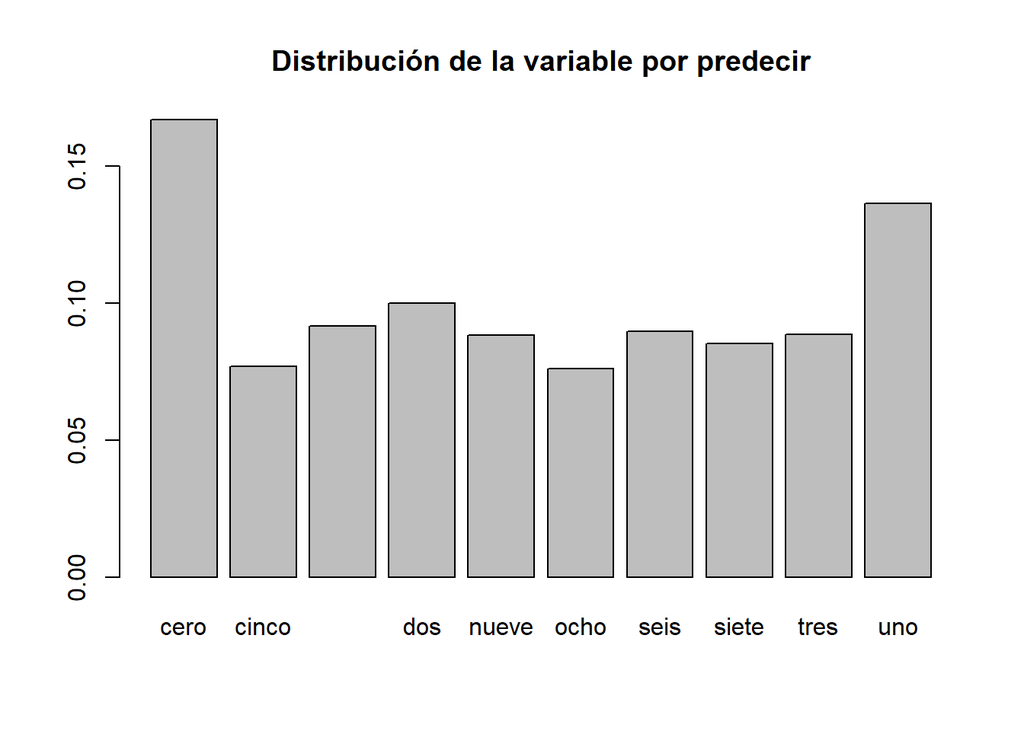

```r
barplot(prop.table(table(data2$Numero)),main="Distribución de la variable por predecir")
```

##Use el metodo de K vecinos mas cercanos en R (con los parametros por defecto) para generar un modelo predictivo para la tabla ZipData 2020.csv usando el 80 % de los datos para la tabla aprendizaje y un 20 % para la tabla testing, luego calcule para los datos de testing la matriz de confusion, la precision global y la precision para cada una de las categorias. ¿Son buenos los resultados? Explique.

```r
tam<-dim(data2)
n<-tam[1]
n
```

```
## [1] 9298
```

```r
muestra <- sample(1:n,floor(n*0.20))
ttesting <- data2[muestra,]
taprendizaje <- data2[-muestra,]
# train.kknn escoje el k usando leave-one-out crossvalidation
modelo<-train.kknn(Numero~.,data=taprendizaje,kmax=floor(sqrt(n)))
modelo
```

```
##
## Call:
## train.kknn(formula = Numero ~ ., data = taprendizaje, kmax = floor(sqrt(n)))
##
## Type of response variable: nominal
## Minimal misclassification: 0.04315096
## Best kernel: optimal
## Best k: 8
```

```r
prediccion<-predict(modelo,ttesting[,-1])
prediccion
```

```
##    [1] cero   cinco  cuatro uno    cero   uno    nueve  nueve  uno    dos
##   [11] ocho   uno    cuatro cinco  uno    seis   seis   ocho   dos    cuatro
##   [21] cero   nueve  dos    tres   uno    cuatro cinco  seis   nueve  cinco
##   [31] ocho   cuatro dos    siete  uno    nueve  tres   uno    uno    cero
##   [41] cero   seis   siete  uno    cero   tres   tres   uno    siete  cero
##   [51] ocho   tres   seis   nueve  dos    cinco  siete  cuatro uno    ocho
##   [61] nueve  uno    seis   seis   ocho   ocho   nueve  dos    ocho   seis
##   [71] uno    cinco  cuatro siete  siete  ocho   uno    siete  dos    siete
##   [81] siete  uno    dos    tres   uno    cinco  uno    cero   tres   cero
##   [91] cero   siete  nueve  uno    cero   seis   tres   siete  uno    dos
##  [101] uno    uno    tres   uno    cuatro cero   uno    cero   siete  cero
##  [111] cero   cero   cuatro nueve  uno    cinco  dos    cuatro cero   tres
##  [121] siete  tres   uno    tres   cero   tres   tres   cinco  cuatro dos
##  [131] siete  cero   dos    cero   nueve  cinco  nueve  uno    seis   siete
##  [141] nueve  dos    siete  ocho   cuatro tres   dos    dos    cuatro nueve
```

[output cut: 172 more lines]

```r
## Matriz de Confusión
MC<-table(ttesting[,1],prediccion)
# Índices de Calidad de la predicción
indices.general(MC)
```

```
## $`Matriz de Confusión`
##         prediccion
##          cero cinco cuatro dos nueve ocho seis siete tres uno
##   cero    332     0      0   1     0    0    0     1    1   0
##   cinco     4   131      0   0     0    1    3     0    4   0
##   cuatro    0     0    143   0     6    0    1     1    0   3
##   dos       2     0      0 194     1    0    1     4    2   1
##   nueve     1     0      2   0   162    0    0     6    1   0
##   ocho      1     1      0   0     1  109    0     2    4   1
##   seis      2     2      0   0     0    0  152     0    0   0
##   siete     0     0      3   1     1    0    0   155    0   0
##   tres      0     2      0   4     0    0    0     4  156   0
##   uno       0     0      0   0     0    0    2     0    0 247
##
## $`Precisión Global`
## [1] 0.958042
##
## $`Error Global`
## [1] 0.04195804
##
## $`Precisión por categoría`
##      cero     cinco    cuatro       dos     nueve      ocho      seis     siete
## 0.9910448 0.9160839 0.9285714 0.9463415 0.9418605 0.9159664 0.9743590 0.9687500
##      tres       uno
## 0.9397590 0.9919679
##
## $`Precision Positiva`
## [1] 0.9703704
##
## $`Precision Negativa`
## [1] 1
##
## $`Falsos Positivos`
## [1] 0
##
## $`Falsos Negativos`
## [1] 0.02962963
##
## $`Asertividad Positiva`
## [1] 1
##
## $`Asertividad Negativa`
## [1] 0.9880952
```